# Data Science Capstone Project

by Christoph

6 Februar 2017

## The data to be used

### The source files

The input data for the later text prediction project consists of 3 files. One from Twitter, one from a blog feed and on from a news feed. Some basic properties for these files are listed below.

```
##                FILE OBJECT SIZE/MB    ROWS MAX TEXT SIZE
## 1    en_US.news.txt            249 1010242         11384
## 2 en_US.twitter.txt            301 2360148           140
## 3   en_US.blogs.txt            248  899288         40833
```

*FILE:* source file name,* OBJECT SIZE:* size in MB when loaded into memory, *ROWS:* amount entries, *MAX TEXT:* The entry with the most characters

## Exploring the files in detail

As the files are quite big and some processing requires a lot of system resources, the following analysis was done against a sample set of these 3 files, randomly gernerated. Sample size per file = 10% of the orginal file.

### 1.) Simple tokenization

First we simply cut the texts into single words, also called tokenization. So we can do some basic statistical operations like counting words. Addionally stop words (e.g. “the”) were excluded, as these don’t give meaning to a text and would appear at the top of any ranking.

The histogram shows the 10 most used words per each of the 3 files.

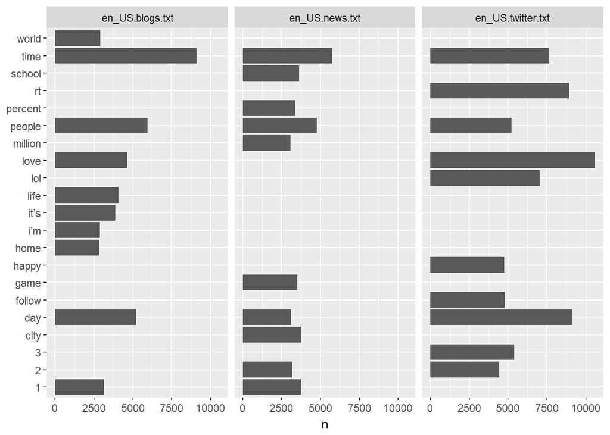

### 2.) Analyzing n-grams

N-grams are combination of words. The next analysis looks at 2-grams, which means basically 2 consecutive words. This is already a good step in the direction of prediction, as it will give us a hint, which could be a reasonable next word following a given word. As with simple word tokenization we have to exclude word combinations with stop words.

The following grafic shows the top 10 most used 2-grams per each of our 3 files:

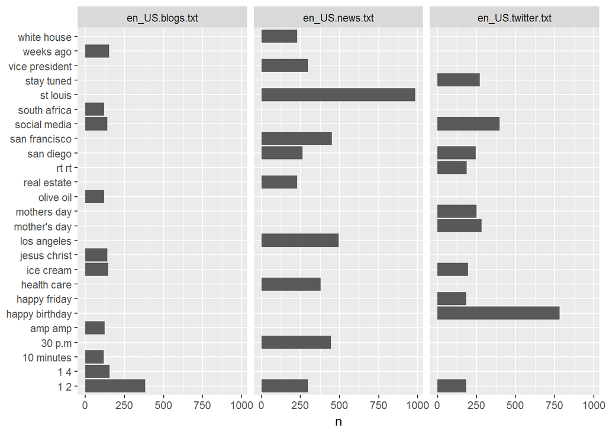

An n-gram analysis can also be visualized as a network, which shows graphically, which word follows another word. In fact this is the visualization of a “Markov chain”." Only combinations with 300 repetitions were considered, otherwise it would look like a big mess:

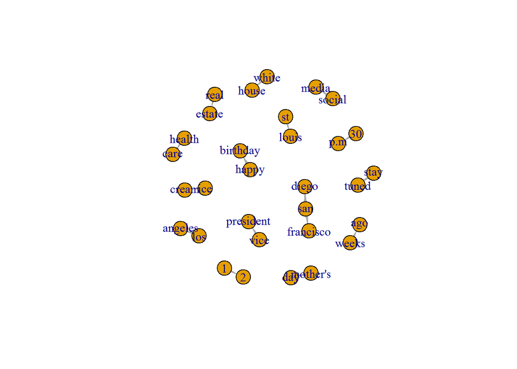

### 3.) “Term frequency” and “Inverse document frequency”

Term frequency gives an impression on word importance in relation to the amount of total words in a text. Additionally “inverse document frequency (idf)” is a technic to up-weight words that appear less frequent over the texts: